# Introduction to Biostatistics

December 26, 2016

## What is Biostatistics?

## Math?

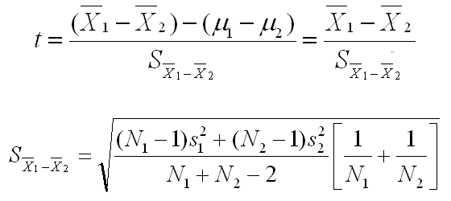

[Source](https://ingenuechasesdenouement.files.wordpress.com/2015/02/formula-for-2-sample-t.png)

## Graphs?

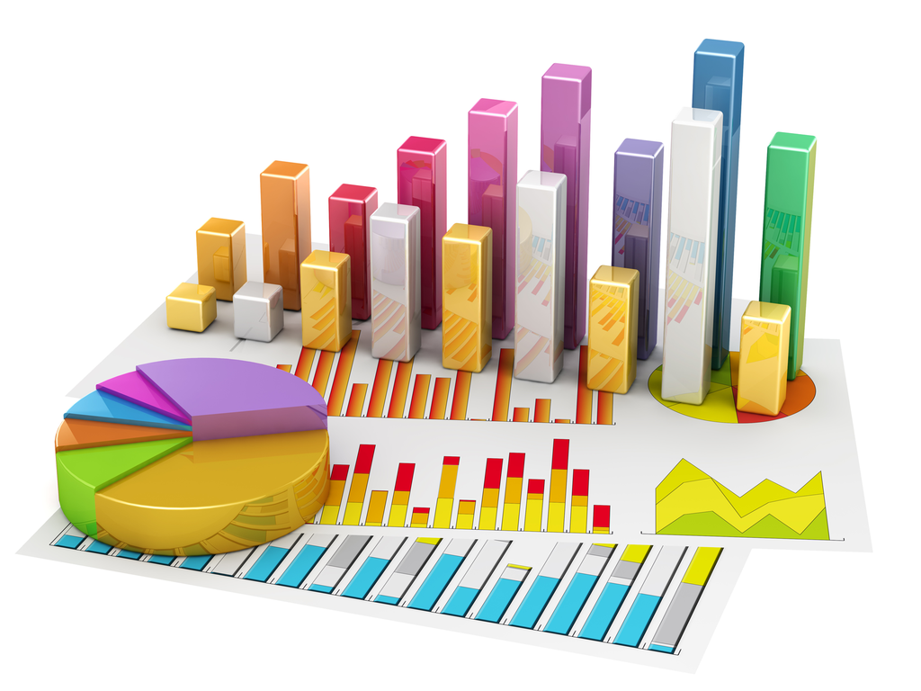

[Source](http://guides.lib.umich.edu/c.php?g=283434&p=2280144)

[figure not shown]

[Source](http://www.someecards.com/usercards/viewcard/MjAxMi0wM2IyMjc3ZGZlYjdhZGIy)

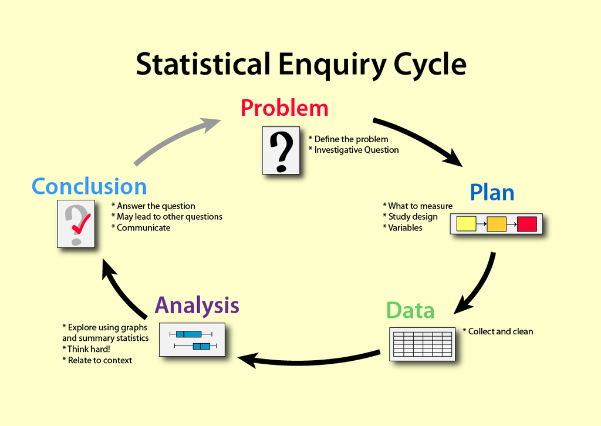

[Source](https://learnandteachstatistics.wordpress.com/2015/07/27/the_islands/)

## Biostatistics

- Theoretical mathematics: building blocks for other researchers
- Applied math: use math to solve a problem like building an estimator
- Biostatistics; using stats with biological data

## Brain imaging

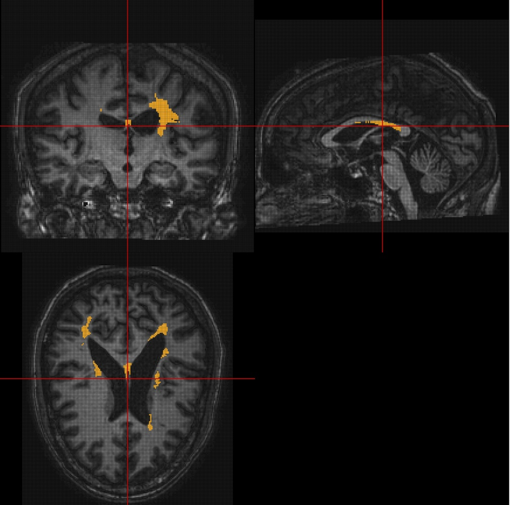

Check out [this interactive visualization](http://johnmuschelli.com/Neuroimaging_in_R/#32)!

[Source](https://elizabethmargaretsweeney.wordpress.com/2015/09/10/introducing-the-oasis-r-package-2/)

## Environmental Statistics

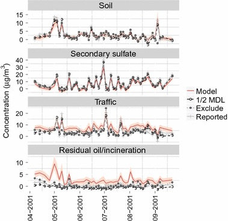

[Source](http://link.springer.com/article/10.1007/s10651-015-0319-6)

## Genomics

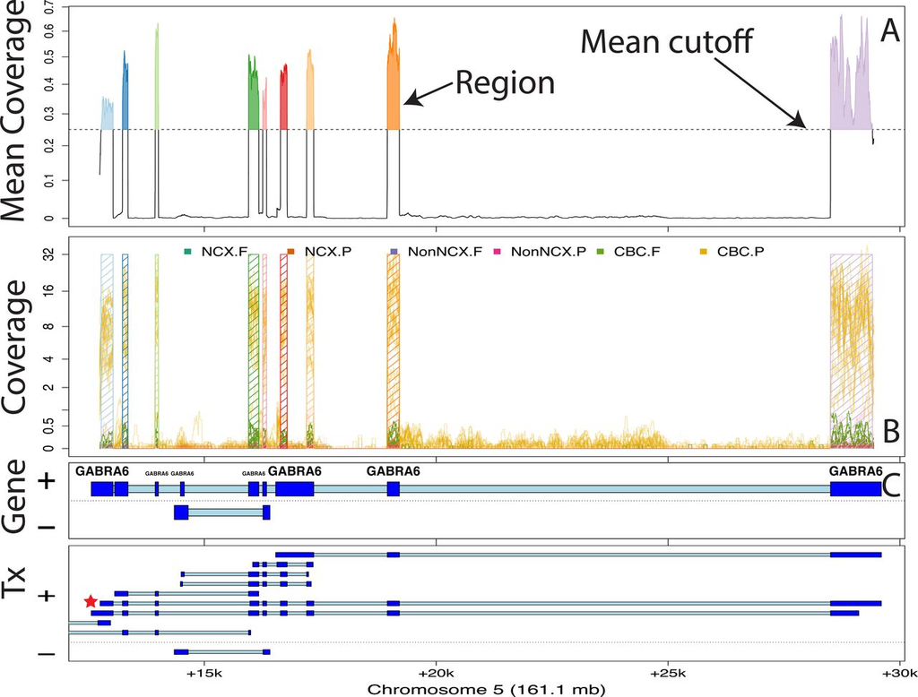

[Source](http://nar.oxfordjournals.org/content/early/2016/09/29/nar.gkw852)

## Activity trackers

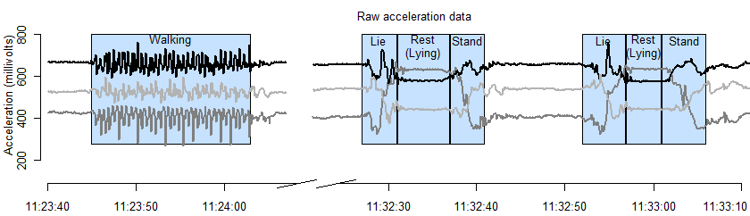

[Source](http://www.biostat.jhsph.edu/~jbai/research.html)

## Cleaning data

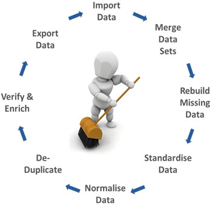

[Source](https://www.linkedin.com/pulse/big-data-101-cleaning-script-fennel-aurora)

## One type of clean data: tidy data

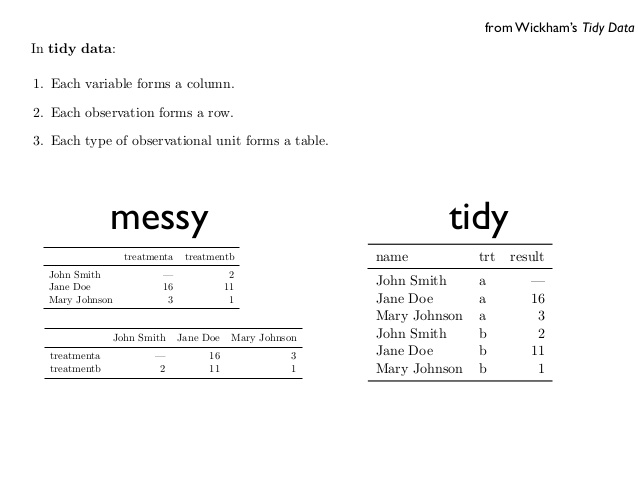

[Source](http://www.slideshare.net/jenniferbryan5811/cm005-intro-ggplot2)

## You'll learn Stata

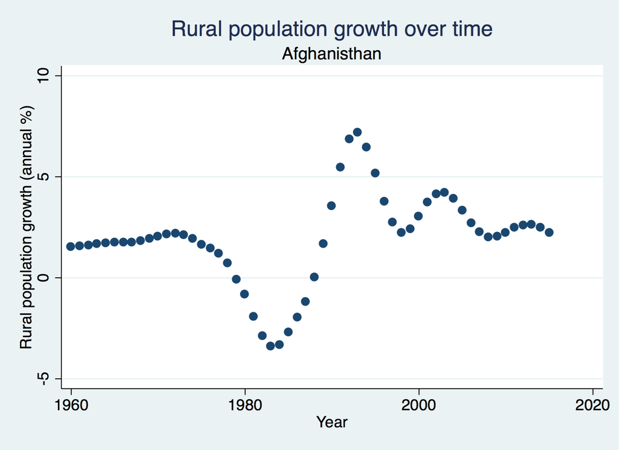

```stata
use afg_worldbank_2016.dta
twoway (scatter SPRURTOTLZG Year), /*
    */ title(Rural population growth over time) /*
    */ subtitle(Afghanisthan)
```

## Modern biostatistician

- Participates in the experimental design, that is the *question* the team wants to answer
- Is a full participant in the research
- Learns how to *clean* data
- Models the data given the question of interest
- Contributes in interpreting the data and suggesting the next steps

## Communicating results

- Understand the main concepts so you can explain them: means understanding why we chose a particular method
- Proper graphics
- Interpretation of the results

## Dr. McGready

Lets take a look at how [John McGready](https://www.jhsph.edu/faculty/directory/profile/801/john-mcgready) introduces biostatistics

- Open lecture 1 of the course *Statistical Reasoning I*

## Exercise

Divide in two teams and come up with a 2 minute overview of Biostatistics. Imagine that you will record a 2 minute video to get students excited about your Biostatistics course.

## Jeff Leek Data Analysis intro

[video not shown]

[Source](https://www.youtube.com/embed/nnQTT39ADPo)